# Perbandingan Performansi Metode Regresi Logistik Biner dan *K-Nearest Neighbor* dalam Memprediksi Penyanyi berdasarkan Karakteristik Lagu

Ilma Amira Rahmayanti

2022-06-01

## 1. Pendahuluan

### 1.1 Latar Belakang

[figure not shown]

Beberapa penyanyi/musisi biasanya mempunyai ciri khas tersendiri dalam membuat dan/atau membawakan sebuah lagu. Dan ada kalanya, beberapa lagu tidak memiliki informasi yang lengkap - salah satunya mungkin tidak adanya informasi mengenai siapa penyanyi/pemilik/pembawa lagu tersebut. Hal ini tentu dapat menghambat pihak *music streaming platform* - atau mungkin para pendengarnya - dalam membuat *playlist* lagu. Namun, tenang saja, kurangnya informasi ini tentu dapat diatasi dengan menggunakan sistem prediksi.

Di dalam *project* ini, saya akan menggunakan data yang berisikan karakteristik dari beberapa lagu, dengan tujuan untuk memprediksi siapakah penyanyi/pemilik lagu-lagu tersebut - dan dengan harapan: metode *machine learning* bisa mempelajari *style* seorang penyanyi/musisi secara historis.

Metode *machine learning* yang digunakan adalah regresi logistik biner dan *k-nearest neighbor*, dimana model akan dibangun berdasarkan kedua metode tersebut, lalu dibuat beberapa prediksi, dan kemudian performa dari kedua metode akan dibandingkan sehingga didapatkan model terbaik.

### 1.2 Tentang Dataset

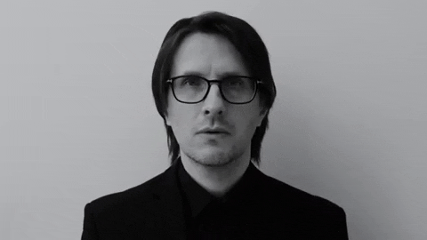

Dataset dalam *project* ini didapatkan dari [kaggle](https://www.kaggle.com/datasets/danielgrijalvas/steven-wilson-analysis), dimana dataset berisikan fitur audio dari 328 lagu di Spotify.

Tujuan dari penggunaan dataset ini adalah untuk memprediksi lagu-lagu yang sesuai dengan karakteristik/*style* Steven Wilson.

Dataset terdiri atas fitur-fitur audio dari 123 lagu Steven Wilson dan 205 lagu musisi lainnya.

Variabel-variabel yang ada dalam dataset meliputi:

- `acousticness`: ukuran yang menggambarkan seberapa akustik lagu tersebut; dimana nilai 1 menggambarkan bahwa lagunya merupakan lagu akustik **[dalam interval 0-1]**
- `album`: nama album dari lagu
- `analysis_url`: URL yang digunakan untuk mendapatkan fitur audio
- `danceability`: ukuran yang menggambarkan betapa cocoknya lagu tersebut digunakan untuk menari; dimana nilai 0 mewakili lagu yang paling tidak cocok dipakai untuk menari dan 1 mewakili lagu yang paling cocok dipakai untuk menari **[dalam interval 0-1]**
- `duration_ms`: durasi lagu dalam ms (miliseconds)
- `energy`: ukuran yang mewakili intensitas atau energi yang dihasilkan suatu lagu; dimana nilai 1 mewakili lagu yang energik dengan ciri-ciri lagunya cepat, keras, dan berisik **[dalam interval 0-1]**
- `id`: ID Spotify dari lagu
- `instrumentalness`: ukuran yang menggambarkan seberapa lama musik instrumen (dimana vokal sedang tidak ada) bermain dalam lagu; dimana nilai di atas 0,5 dimaksudkan untuk mewakili lagu instrumental **[dalam interval 0-1]**
- `key`: kunci dari lagu [0 = C, 1 = C♯/D, 2 = D, dan seterusnya]
- `liveness`: ukuran kepercayaan untuk mendeteksi kehadiran penonton dalam rekaman; dimana 1 mewakili kepercayaan yang tinggi bahwa lagu tersebut dibawakan secara *live* **[dalam interval 0-1]**
- `loudness`: ukuran yang menggambarkan seberapa nyaring lagu; dimana nilai 1 mewakili lagu yang tidak nyaring dan 0 mewakili lagu yang nyaring **[dalam interval 0-1]**
- `mode`: modalitas dalam lagu [1 = major, 0 = minor]
- `name`: nama lagu
- `speechiness`: ukuran yang menggambarkan seberapa banyak keberadaan *spoken words* dalam lagu; semakin eksklusif rekaman, seperti pada pidato/acara *talkshow*, nilai atributnya semakin mendekati 1 **[dalam interval 0-1]**
- `tempo`: ukuran yang menggambarkan keseluruhan tempo pada lagu; dimana nilai 1 mewakili lagu dengan tempo cepat **[dalam interval 0-1]**
- `time_signature`: *time signature* dari suatu lagu - atau yang menentukan berapa banyak ketukan di setiap bar; misalnya: 3/4, 4/4, 5/4, dan seterusnya
- `track_href`: tautan API Spotify dari lagu
- `type`: tipe data
- `uri`: URI Spotify dari lagu
- `valence`: ukuran yang menggambarkan kepositifan lagu; lagu dengan *valence* tinggi bersifat lebih positif (bersifat bahagia, ceria, euforia), sedangkan lagu dengan *valence* rendah bersifat lebih negatif (bersifat sedih, tertekan, marah) **[dalam interval 0-1]**
- `class`: penyanyi lagu [0 = Penyanyi lain, 1 = Steven Wilson]

## 2. *Load Library*

Pertama-tama, *load* terlebih dahulu *library* yang dibutuhkan.

```r
# load library
library(stringr) # untuk replace karakter
library(dplyr) # untuk transformasi data
library(GGally) # untuk EDA
library(rsample) # untuk train-test splitting
library(caret) # untuk membuat confusion matrix
library(car) # untuk cek multikolinieritas
library(class) # untuk knn
library(DT) # untuk membuat datatable
```

## 3. *Read Data*

Baca dataset **song.csv** yang akan digunakan.

```r
# read data
song <- read.csv("data_input/song.csv", header=T, na.strings=c(""))
```

|  | acousticness | album | analysis_url | danceability | duration_ms | energy | id | instrumentalness | key | liveness | loudness | mode | name | speechiness | tempo | time_signature | track_href | type | uri | valence | class.. |
| --- | --- | --- | --- | --- | --- | --- | --- | --- | --- | --- | --- | --- | --- | --- | --- | --- | --- | --- | --- | --- | --- |
| 1 | 0.732 | Grace for Drowning | https://api.spotify.com/v1/audio-analysis/1mAfaiS8yke7hG73sp3keZ | 0.196 | 0.327470613965242 | 0.171 | 1mAfaiS8yke7hG73sp3keZ | 0.68 | 11 | 0.0753 | 0.680058914982407 | 0 | Deform to Form a Star | 0.0376 | 0.392945919073145 | 4 | https://api.spotify.com/v1/tracks/1mAfaiS8yke7hG73sp3keZ | audio_features | spotify:track:1mAfaiS8yke7hG73sp3keZ | 0.049 | 1;; |
| 2 | 0.0277 | Grace for Drowning | https://api.spotify.com/v1/audio-analysis/6eM6LP9zOo93sDaQpOi7Iv | 0.456 | 0.239561812028125 | 0.427 | 6eM6LP9zOo93sDaQpOi7Iv | 0.412 | 0 | 0.0983 | 0.579862531707716 | 0 | No Part of Me | 0.0328 | 0.875470127961266 | 4 | https://api.spotify.com/v1/tracks/6eM6LP9zOo93sDaQpOi7Iv | audio_features | spotify:track:6eM6LP9zOo93sDaQpOi7Iv | 0.17 | 1;; |
| 3 | 0.75 | Grace for Drowning | https://api.spotify.com/v1/audio-analysis/60GnLUvlb4fUHThzG8rZDT | 0.464 | 0.18681333200743 | 0.249 | 60GnLUvlb4fUHThzG8rZDT | 0.408 | 0 | 0.0969 | 0.574052859831438 | 1 | Postcard | 0.0294 | 0.713135483313159 | 4 | https://api.spotify.com/v1/tracks/60GnLUvlb4fUHThzG8rZDT | audio_features | spotify:track:60GnLUvlb4fUHThzG8rZDT | 0.0914 | 1;; |
| 4 | 0.319 | Grace for Drowning | https://api.spotify.com/v1/audio-analysis/1MCamKVAN8QA68QYqpdCCy | 0.418 | 0.39428503080292 | 0.443 | 1MCamKVAN8QA68QYqpdCCy | 0.876 | 9 | 0.0588 | 0.552941657802144 | 0 | Remainder the Black Dog | 0.0264 | 0.525062683728169 | 4 | https://api.spotify.com/v1/tracks/1MCamKVAN8QA68QYqpdCCy | audio_features | spotify:track:1MCamKVAN8QA68QYqpdCCy | 0.28 | 1;; |
| 5 | 0.893 | Grace for Drowning | https://api.spotify.com/v1/audio-analysis/3gZLvp9VKl0S96S2Rv81xk | 0.362 | 0.124774254474751 | 0.0911 | 3gZLvp9VKl0S96S2Rv81xk | 0.817 | 7 | 0.121 | 0.859872350871451 | 1 | Belle De Jour | 0.0373 | 0.991008127269583 | 4 | https://api.spotify.com/v1/tracks/3gZLvp9VKl0S96S2Rv81xk | audio_features | spotify:track:3gZLvp9VKl0S96S2Rv81xk | 0.0353 | 1;; |
| 6 | 0.799 | Grace for Drowning | https://api.spotify.com/v1/audio-analysis/1uoswgp0iFqFUOGxpMfniQ | 0.126 | 0.334508102499769 | 0.0539 | 1uoswgp0iFqFUOGxpMfniQ | 0.509 | 9 | 0.0901 | 0.832665084690287 | 1 | Like Dust I Have Cleared from My Eye | 0.0459 | 0.446189261628912 | 4 | https://api.spotify.com/v1/tracks/1uoswgp0iFqFUOGxpMfniQ | audio_features | spotify:track:1uoswgp0iFqFUOGxpMfniQ | 0.038 | 1;; |
| 7 | 0.00221 | The Raven That Refused to Sing (And Other Stories) | https://api.spotify.com/v1/audio-analysis/033qZdFc0NDMcC5qgwuUux | 0.416 | 0.507728372413879 | 0.447 | 033qZdFc0NDMcC5qgwuUux | 0.604 | 4 | 0.083 | 0.43314786024057 | 0 | Luminol | 0.0309 | 0.930064412934463 | 4 | https://api.spotify.com/v1/tracks/033qZdFc0NDMcC5qgwuUux | audio_features | spotify:track:033qZdFc0NDMcC5qgwuUux | 0.288 | 1;; |
| 8 | 0.0414 | The Raven That Refused to Sing (And Other Stories) | https://api.spotify.com/v1/audio-analysis/4kZbYkUuDHyphD71bPMYL1 | 0.447 | 0.317973481463659 | 0.349 | 4kZbYkUuDHyphD71bPMYL1 | 0.401 | 2 | 0.102 | 0.475738482939203 | 1 | Drive Home | 0.0314 | 0.6696351374719 | 4 | https://api.spotify.com/v1/tracks/4kZbYkUuDHyphD71bPMYL1 | audio_features | spotify:track:4kZbYkUuDHyphD71bPMYL1 | 0.0756 | 1;; |
| 9 | 0.000791 | The Raven That Refused to Sing (And Other Stories) | https://api.spotify.com/v1/audio-analysis/2Be2FRwYOryoBs15fWt9FK | 0.297 | 0.21000644639513 | 0.675 | 2Be2FRwYOryoBs15fWt9FK | 0.00167 | 7 | 0.22 | 0.356926601751084 | 1 | The Pin Drop | 0.0471 | 0.705343247449421 | 4 | https://api.spotify.com/v1/tracks/2Be2FRwYOryoBs15fWt9FK | audio_features | spotify:track:2Be2FRwYOryoBs15fWt9FK | 0.04 | 1;; |
| 10 | 0.185 | The Raven That Refused to Sing (And Other Stories) | https://api.spotify.com/v1/audio-analysis/7tXMYAIKHQ2nQ6hrJ4OnTV | 0.315 | 0.488182652034439 | 0.294 | 7tXMYAIKHQ2nQ6hrJ4OnTV | 0.045 | 7 | 0.0776 | 0.454177235905409 | 0 | The Watchmaker | 0.0334 | 0.681134359329068 | 4 | https://api.spotify.com/v1/tracks/7tXMYAIKHQ2nQ6hrJ4OnTV | audio_features | spotify:track:7tXMYAIKHQ2nQ6hrJ4OnTV | 0.0963 | 1;; |

[output cut: 328 more lines]

Dari tabel di atas, dapat diidentifikasi bahwa variabel targetnya adalah `class..` dan variabel prediktornya (sementara ini) adalah variabel sisanya.

Namun sebelum lanjut ke pemodelan, kita harus memeriksa terlebih dahulu kesesuaian struktur data yang akan dipakai dan melakukan *cleansing* (jika perlu).

## 4. *Data Cleansing*

Lihat struktur data `song` untuk mengecek kesesuaian tipe data.

```r
# lihat struktur data
str(song)
```

```
## 'data.frame':    338 obs. of  21 variables:
##  $ acousticness    : chr  "0.732" "0.0277" "0.75" "0.319" ...
##  $ album           : chr  "Grace for Drowning" "Grace for Drowning" "Grace for Drowning" "Grace for Drowning" ...
##  $ analysis_url    : chr  "https://api.spotify.com/v1/audio-analysis/1mAfaiS8yke7hG73sp3keZ" "https://api.spotify.com/v1/audio-analysis/6eM6LP9zOo93sDaQpOi7Iv" "https://api.spotify.com/v1/audio-analysis/60GnLUvlb4fUHThzG8rZDT" "https://api.spotify.com/v1/audio-analysis/1MCamKVAN8QA68QYqpdCCy" ...
##  $ danceability    : num  0.196 0.456 0.464 0.418 0.362 0.126 0.416 0.447 0.297 0.315 ...
##  $ duration_ms     : num  0.327 0.24 0.187 0.394 0.125 ...
##  $ energy          : num  0.171 0.427 0.249 0.443 0.0911 0.0539 0.447 0.349 0.675 0.294 ...
##  $ id              : chr  "1mAfaiS8yke7hG73sp3keZ" "6eM6LP9zOo93sDaQpOi7Iv" "60GnLUvlb4fUHThzG8rZDT" "1MCamKVAN8QA68QYqpdCCy" ...
##  $ instrumentalness: num  0.68 0.412 0.408 0.876 0.817 0.509 0.604 0.401 0.00167 0.045 ...
##  $ key             : int  11 0 0 9 7 9 4 2 7 7 ...
##  $ liveness        : num  0.0753 0.0983 0.0969 0.0588 0.121 0.0901 0.083 0.102 0.22 0.0776 ...
##  $ loudness        : num  0.68 0.58 0.574 0.553 0.86 ...
##  $ mode            : int  0 0 1 0 1 1 0 1 1 0 ...
##  $ name            : chr  "Deform to Form a Star" "No Part of Me" "Postcard" "Remainder the Black Dog" ...
##  $ speechiness     : num  0.0376 0.0328 0.0294 0.0264 0.0373 0.0459 0.0309 0.0314 0.0471 0.0334 ...
##  $ tempo           : num  0.393 0.875 0.713 0.525 0.991 ...
##  $ time_signature  : int  4 4 4 4 4 4 4 4 4 4 ...
##  $ track_href      : chr  "https://api.spotify.com/v1/tracks/1mAfaiS8yke7hG73sp3keZ" "https://api.spotify.com/v1/tracks/6eM6LP9zOo93sDaQpOi7Iv" "https://api.spotify.com/v1/tracks/60GnLUvlb4fUHThzG8rZDT" "https://api.spotify.com/v1/tracks/1MCamKVAN8QA68QYqpdCCy" ...
##  $ type            : chr  "audio_features" "audio_features" "audio_features" "audio_features" ...
##  $ uri             : chr  "spotify:track:1mAfaiS8yke7hG73sp3keZ" "spotify:track:6eM6LP9zOo93sDaQpOi7Iv" "spotify:track:60GnLUvlb4fUHThzG8rZDT" "spotify:track:1MCamKVAN8QA68QYqpdCCy" ...
##  $ valence         : num  0.049 0.17 0.0914 0.28 0.0353 0.038 0.288 0.0756 0.04 0.0963 ...
##  $ class..         : chr  "1;;" "1;;" "1;;" "1;;" ...
```

Berdasarkan struktur data di atas, dapat dilihat bahwa ada beberapa hal yang perlu diperbaiki (di-*cleansing*). *Workflow* dari *data cleansing* meliputi:

1. Menghapus karakter “;;” dan “;” pada variabel `class..` agar nantinya variabel tersebut dapat diubah tipe datanya menjadi faktor (dalam hal ini, hasil perbaikannya saya simpan pada kolom baru, yaitu `class`).
2. Menghapus variabel yang tidak diperlukan, yaitu `class..` dan `type`. Variabel `type` saya hapus karena berisikan nilai yang sama untuk semua atributnya.
3. Mengubah tipe data dari variabel `class` menjadi integer, agar nantinya tidak timbul masalah saat tipe datanya diubah menjadi faktor.
4. Mengecek *missing value*.
5. Menghapus baris yang mengandung *missing value* karena tidak ada informasi lain yang dapat digunakan untuk imputasi/mengisi *missing value*.
6. Mengecek kembali *missing value*. Jika sudah tidak ada *missing value*, maka dilanjutkan ke tahap berikutnya.
7. Mengecek adanya data *duplicate*. Jika tidak ada data *duplicate*, bisa langsung dilanjutkan ke tahap berikutnya.
8. Mengubah tipe data yang belum sesuai, meliputi:
   - Mengubah tipe data dari variabel `acousticness`, `danceability`, `duration_ms`, `energy`, `instrumentalness`, `liveness`, `loudness`, `speechiness`, `tempo`, `valence` menjadi numerik.
   - Mengubah tipe data dari variabel `key`, `mode`, `time_signature`, `class` menjadi faktor.
9. Mengecek kembali struktur data dengan menggunakan glimpse().
10. Mengubah nama level pada variabel `key`, `mode`, `time_signature` agar mudah untuk diinterpretasi.
11. Menghapus variabel yang bertipe karakter (yaitu `album`, `analysis_url`, `id`, `name`, `track_href`, `uri`) karena variabel dengan banyak nilai unik tidak dapat digunakan untuk pemodelan.
12. *Dataframe* yang telah dilakukan perubahan dan penghapusan variabel disimpan ke dalam *dataframe* baru, yaitu **song_clean**.
13. Melihat struktur data dari **song_clean**. Apabila telah sesuai, dapat dilanjutkan ke Analisis Data Eksploratori (EDA).

```r
# menghapus karakter yang tidak diperlukan
song$class <- str_replace_all(song$class.., ";;", "")
song$class <- str_replace_all(song$class.., ";", "")
```

```r
# menghapus kolom yang tidak diperlukan
# mengubah tipe data class
song <- song %>%
  select(-c(class.., type)) %>%
  mutate(class = as.integer(class))
```

```r
# mengecek missing value
colSums(is.na(song))
```

```
##     acousticness            album     analysis_url     danceability
##                0               10               10               10
##      duration_ms           energy               id instrumentalness
##               10               10               10               10
##              key         liveness         loudness             mode
##               10               10               10               10
##             name      speechiness            tempo   time_signature
##               10               10               10               10
##       track_href              uri          valence            class
##               10               10               10               10
```

Ternyata ada *missing value*.

```r
# menghapus baris yang mengandung missing value
song <- song[rowSums(is.na(song)) == 0,]
```

```r
# mengecek kembali missing value
colSums(is.na(song))
```

```
##     acousticness            album     analysis_url     danceability
##                0                0                0                0
##      duration_ms           energy               id instrumentalness
##                0                0                0                0
##              key         liveness         loudness             mode
##                0                0                0                0
##             name      speechiness            tempo   time_signature
##                0                0                0                0
##       track_href              uri          valence            class
##                0                0                0                0
```

Sudah tidak ada *missing value*.

```r
# mengecek duplikasi
nrow(song[duplicated(song$id),])
```

```
## [1] 0
```

Tidak ada data *duplicate*.

```r
# mengubah tipe data
song <- song %>%
  mutate_at(vars(acousticness, danceability, duration_ms, energy, instrumentalness, liveness, loudness, speechiness, tempo, valence), as.numeric) %>%
  mutate_at(vars(key, mode, time_signature, class), as.factor)
```

```r
# mengintip tipe dan struktur data
glimpse(song)
```

```
## Rows: 328
## Columns: 20
## $ acousticness     <dbl> 0.732000, 0.027700, 0.750000, 0.319000, 0.893000, 0.7~
## $ album            <chr> "Grace for Drowning", "Grace for Drowning", "Grace fo~
## $ analysis_url     <chr> "https://api.spotify.com/v1/audio-analysis/1mAfaiS8yk~
## $ danceability     <dbl> 0.196, 0.456, 0.464, 0.418, 0.362, 0.126, 0.416, 0.44~
## $ duration_ms      <dbl> 0.3274706, 0.2395618, 0.1868133, 0.3942850, 0.1247743~
## $ energy           <dbl> 0.1710, 0.4270, 0.2490, 0.4430, 0.0911, 0.0539, 0.447~
## $ id               <chr> "1mAfaiS8yke7hG73sp3keZ", "6eM6LP9zOo93sDaQpOi7Iv", "~
## $ instrumentalness <dbl> 0.680000, 0.412000, 0.408000, 0.876000, 0.817000, 0.5~
## $ key              <fct> 11, 0, 0, 9, 7, 9, 4, 2, 7, 7, 5, 11, 2, 0, 2, 1, 4, ~
## $ liveness         <dbl> 0.0753, 0.0983, 0.0969, 0.0588, 0.1210, 0.0901, 0.083~
## $ loudness         <dbl> 0.6800589, 0.5798625, 0.5740529, 0.5529417, 0.8598724~
## $ mode             <fct> 0, 0, 1, 0, 1, 1, 0, 1, 1, 0, 1, 0, 0, 1, 1, 0, 0, 1,~
## $ name             <chr> "Deform to Form a Star", "No Part of Me", "Postcard",~
## $ speechiness      <dbl> 0.0376, 0.0328, 0.0294, 0.0264, 0.0373, 0.0459, 0.030~
## $ tempo            <dbl> 0.3929459, 0.8754701, 0.7131355, 0.5250627, 0.9910081~
## $ time_signature   <fct> 4, 4, 4, 4, 4, 4, 4, 4, 4, 4, 4, 4, 4, 3, 4, 3, 4, 5,~
## $ track_href       <chr> "https://api.spotify.com/v1/tracks/1mAfaiS8yke7hG73sp~
## $ uri              <chr> "spotify:track:1mAfaiS8yke7hG73sp3keZ", "spotify:trac~
## $ valence          <dbl> 0.0490, 0.1700, 0.0914, 0.2800, 0.0353, 0.0380, 0.288~
## $ class            <fct> 1, 1, 1, 1, 1, 1, 1, 1, 1, 1, 1, 1, 1, 1, 1, 1, 1, 1,~
```

```r
# mengubah nama level variabel key
levels(song$key) <- list('C' = "0",
                         'C#/Db' = "1",
                         'D' = "2",
                         'D#/Eb' = "3",
                         'E' = "4",
                         'F' = "5",
                         'F#/Gb' = "6",
                         'G' = "7",
                         'G#/Ab' = "8",
                         'A' = "9",
                         'A#/Bb' = "10",
                         'B' = "11")
```

```r
# mengubah nama level variabel mode
levels(song$mode) <- list("minor" = "0", "major" = "1")
```

```r
# mengubah nama level variabel time_signature
levels(song$time_signature) <- list('3/4' = "1",
                                    '4/4' = "2",
                                    '5/4' = "3",
                                    '6/4' = "4",
                                    '7/4' = "5")
```

```r
# membuat data frame baru
# data frame berisi variabel yang bukan bertipe character
song_clean <- song %>%
  select(-c(album, analysis_url, id, name, track_href, uri))
```

```r
# mengintip tipe dan struktur data dari dataframe baru
glimpse(song_clean)
```

```
## Rows: 328
## Columns: 14
## $ acousticness     <dbl> 0.732000, 0.027700, 0.750000, 0.319000, 0.893000, 0.7~
## $ danceability     <dbl> 0.196, 0.456, 0.464, 0.418, 0.362, 0.126, 0.416, 0.44~
## $ duration_ms      <dbl> 0.3274706, 0.2395618, 0.1868133, 0.3942850, 0.1247743~
## $ energy           <dbl> 0.1710, 0.4270, 0.2490, 0.4430, 0.0911, 0.0539, 0.447~
## $ instrumentalness <dbl> 0.680000, 0.412000, 0.408000, 0.876000, 0.817000, 0.5~
## $ key              <fct> B, C, C, A, G, A, E, D, G, G, F, B, D, C, D, C#/Db, E~
## $ liveness         <dbl> 0.0753, 0.0983, 0.0969, 0.0588, 0.1210, 0.0901, 0.083~
## $ loudness         <dbl> 0.6800589, 0.5798625, 0.5740529, 0.5529417, 0.8598724~
## $ mode             <fct> minor, minor, major, minor, major, major, minor, majo~
## $ speechiness      <dbl> 0.0376, 0.0328, 0.0294, 0.0264, 0.0373, 0.0459, 0.030~
## $ tempo            <dbl> 0.3929459, 0.8754701, 0.7131355, 0.5250627, 0.9910081~
## $ time_signature   <fct> 6/4, 6/4, 6/4, 6/4, 6/4, 6/4, 6/4, 6/4, 6/4, 6/4, 6/4~
## $ valence          <dbl> 0.0490, 0.1700, 0.0914, 0.2800, 0.0353, 0.0380, 0.288~
## $ class            <fct> 1, 1, 1, 1, 1, 1, 1, 1, 1, 1, 1, 1, 1, 1, 1, 1, 1, 1,~
```

Data **song_clean** sudah sesuai. Lanjut ke tahap berikutnya.

> Mulai titik ini, dataset yang digunakan adalah **song_clean**.

## 5. Analisis Data Eksploratori

Sebelum menganalisis lebih jauh tentang pengaruh variabel prediktor terhadap variabel target, sebaiknya terlebih dahulu memeriksa hubungan antara variabel prediktor dan variabel target. Hal ini dilakukan sekaligus sebagai langkah untuk menyeleksi fitur (*feature selection*).

Variabel target pada dataset memiliki tipe data faktor, sedangkan variabel prediktornya ada yang bertipe faktor (kategorik) dan numerik.

Dengan demikian, untuk memeriksa hubungan antara variabel prediktor numerik dengan variabel target, akan digunakan uji perbedaan rata-rata dua populasi independen (dimana rata-rata populasi antara dua kelas target akan diuji perbedaannya - saling berbeda atau tidak). Uji yang diterapkan dalam *project* ini adalah Mann-Whitney U Test (walaupun tidak dibahas lebih jauh pada *markdown* ini); dimana jika hasil pengujian menghasilkan hasil yang signifikan, berarti terdapat perbedaan rata-rata antara dua kelas target, atau secara intuisi dapat dinilai bahwa ada hubungan antara variabel prediktor numerik dan variabel target.

Selain itu, akan dicek pula distribusi nilai variabel prediktor numerik untuk setiap level kelas targetnya. Hal ini juga dilakukan untuk menggambarkan secara garis besar - apakah ada perbedaan distribusi antar level kelas target.

Sedangkan untuk memeriksa hubungan antara variabel prediktor kategorik dengan variabel target, akan digunakan Chi-Square Test; dimana jika hasil pengujian menghasilkan hasil yang signifikan, berarti terdapat hubungan antara dua variabel tersebut.

*Feature selection* pada *project* ini juga memperhatikan opini dari referensi utama. Lihat dokumentasinya [di sini](https://www.kaggle.com/code/danielgrijalvas/finding-songs-that-match-sw-s-style-using-knn).

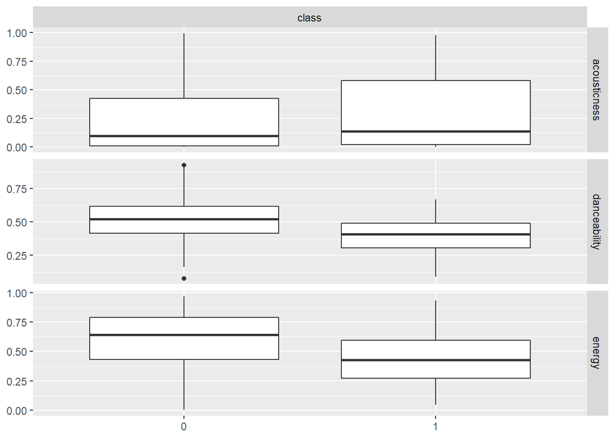

```r
# mengecek distribusi nilai dari variabel prediktor untuk setiap level class
ggduo(song_clean,
      "class",
      c("acousticness", "danceability", "energy"))
```

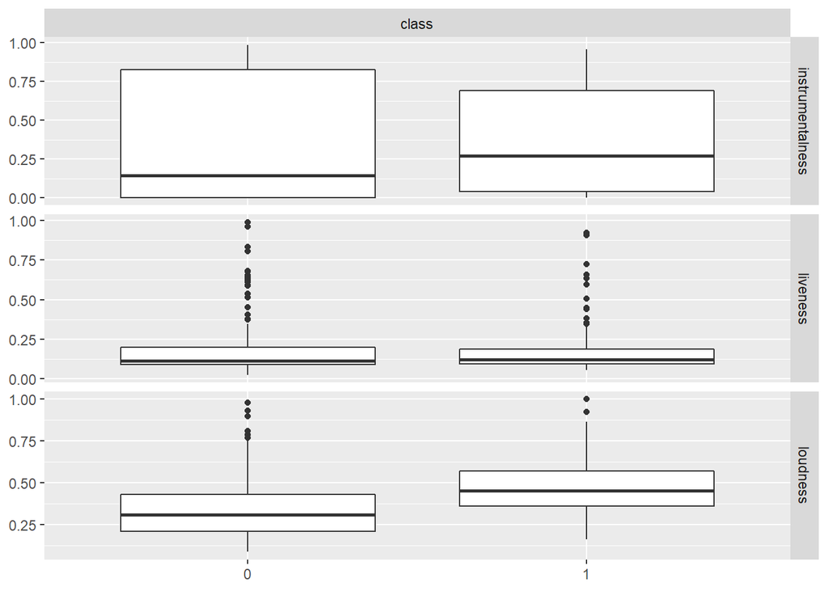

```r
# mengecek distribusi nilai dari variabel prediktor untuk setiap level class
ggduo(song_clean,
      "class",
      c("instrumentalness", "liveness", "loudness"))
```

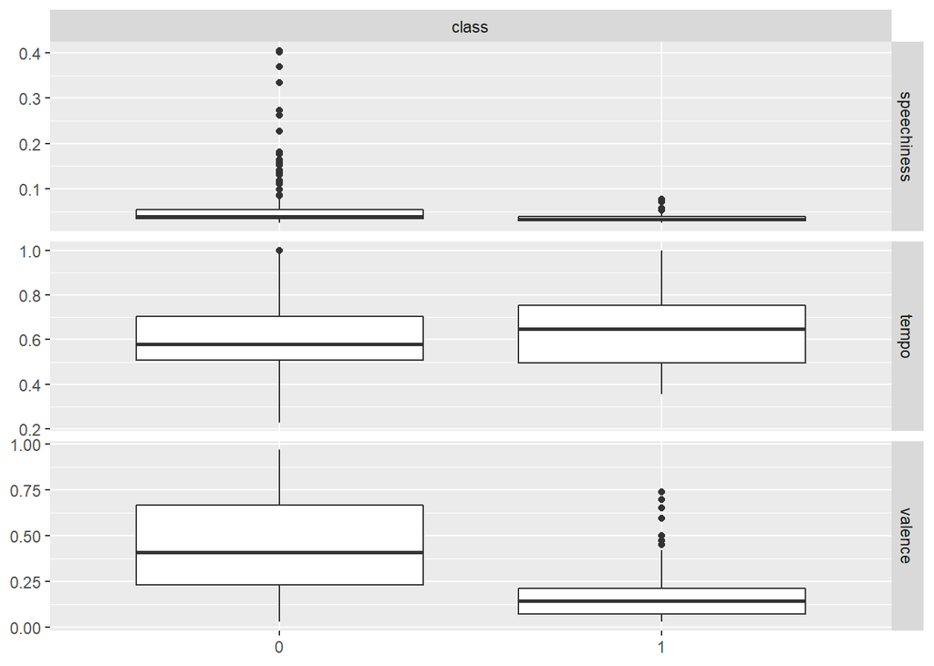

```r
# mengecek distribusi nilai dari variabel prediktor untuk setiap level class
ggduo(song_clean,
      "class",
      c("speechiness", "tempo", "valence"))
```

Berdasarkan uji Mann-Whitney U dan tiga gambar di atas, variabel prediktor numerik yang ditengarai memiliki hubungan dengan variabel target adalah: `danceability`, `energy`, `loudness`, `speechiness`, `valence`. Namun, jika dipikir secara logika, `speechiness` sepertinya tidak ada hubungannya dengan target. Hal ini sejalan dengan referensi utama [(lihat di sini)](https://www.kaggle.com/code/danielgrijalvas/finding-songs-that-match-sw-s-style-using-knn); ditambah nilainya yang mengandung banyak *outlier*, membuat saya memutuskan untuk menghapus variabel `speechiness` dari variabel prediktor.

Sedangkan menurut referensi utama [(lihat di sini)](https://www.kaggle.com/code/danielgrijalvas/finding-songs-that-match-sw-s-style-using-knn), terdapat *concern* bahwa: sepertinya, variabel `instrumentalness` dan `acousticness` memiliki hubungan dengan variabel target - dan ini masuk akal. Oleh karena itu, saya pun memutuskan untuk memasukkan dua variabel tersebut ke dalam variabel prediktor.

Di bawah ini akan dilakukan uji korelasi antara variabel prediktor kategorik dengan variabel target. Selanjutnya, akan diidentifikasi pula apakah ada variabel prediktor yang bersifat *perfect separator*.

```r
# cek perfect separator
table(song_clean$key, song_clean$class)
```

```
##
##          0  1
##   C     26 21
##   C#/Db 16  4
##   D     26 21
##   D#/Eb  7  2
##   E     17 19
##   F     20 10
##   F#/Gb 10  5
##   G     20 14
##   G#/Ab  9  2
##   A     26 16
##   A#/Bb 13  2
##   B     15  7
```

Bukan *perfect separator*.

```r
# mengecek hubungan variabel key dengan target
chisq.test(table(song_clean$key, song_clean$class))
```

```
##
##  Pearson's Chi-squared test
##
## data:  table(song_clean$key, song_clean$class)
## X-squared = 15.491, df = 11, p-value = 0.1611
```

```r
# cek perfect separator
table(song_clean$mode, song_clean$class)
```

```
##
##           0   1
##   minor  74  63
##   major 131  60
```

Bukan *perfect separator*.

```r
# mengecek hubungan variabel mode dengan target
chisq.test(table(song_clean$mode, song_clean$class))
```

```
##
##  Pearson's Chi-squared test with Yates' continuity correction
##
## data:  table(song_clean$mode, song_clean$class)
## X-squared = 6.6192, df = 1, p-value = 0.01009
```

```r
# menghapus level yang tidak ada anggotanya
song_clean$time_signature <- droplevels(song_clean$time_signature)
```

```r
# cek perfect separator
table(song_clean$time_signature, song_clean$class)
```

```
##
##         0   1
##   3/4   4   3
##   5/4  30  16
##   6/4 165 101
##   7/4   6   3
```

Bukan *perfect separator*.

```r
# mengecek hubungan variabel time_signature dengan target
chisq.test(table(song_clean$time_signature, song_clean$class))
```

```
##
##  Pearson's Chi-squared test
##
## data:  table(song_clean$time_signature, song_clean$class)
## X-squared = 0.32237, df = 3, p-value = 0.9558
```

Dari hasil ketiga uji Chi-Square di atas, variabel prediktor kategorik yang memiliki korelasi dengan variabel target adalah variabel `mode`.

Dengan demikian, variabel yang digunakan dalam pemodelan adalah:

- `danceability`
- `energy`
- `loudness`
- `valence`
- `instrumentalness`
- `acousticness`
- `mode`

> **Disclaimer:** variabel `duration_ms` diputuskan untuk tidak digunakan dalam pemodelan karena terdiri dari nilai-nilai yang aneh dan tidak konsisten (ada yang desimal dan ada juga yang ratusan ribu)

```r
# menghapus variabel yang tidak digunakan di dataframe baru
song_clean <- song_clean %>%
  select(c(danceability, energy, loudness, valence, instrumentalness, acousticness, mode, class))
```

```r
# melihat summary dari dataframe baru
summary(song_clean)
```

```
##   danceability        energy           loudness          valence
##  Min.   :0.0778   Min.   :0.00374   Min.   :0.08781   Min.   :0.0299
##  1st Qu.:0.3568   1st Qu.:0.33800   1st Qu.:0.24986   1st Qu.:0.1270
##  Median :0.4670   Median :0.55400   Median :0.37276   Median :0.2815
##  Mean   :0.4740   Mean   :0.53570   Mean   :0.39824   Mean   :0.3421
##  3rd Qu.:0.5663   3rd Qu.:0.74375   3rd Qu.:0.50797   3rd Qu.:0.5102
##  Max.   :0.9270   Max.   :0.96700   Max.   :1.00000   Max.   :0.9700
##  instrumentalness   acousticness          mode     class
##  Min.   :0.00000   Min.   :0.0000085   minor:137   0:205
##  1st Qu.:0.00308   1st Qu.:0.0146000   major:191   1:123
##  Median :0.23800   Median :0.1090000
##  Mean   :0.37491   Mean   :0.2768855
##  3rd Qu.:0.77850   3rd Qu.:0.4645000
##  Max.   :0.98600   Max.   :0.9940000
```

Menurut *summary* di atas, dapat disimpulkan bahwa: nilai dari variabel prediktor numerik kebanyakan berada di rentang 0 dan 1.

Setelah variabel prediktor berhasil dipilih, akan dilakukan pengecekan asumsi regresi logistik - terpenuhi atau tidak, dimana salah satu asumsi dari regresi logistik adalah tidak adanya multikolinieritas. Oleh karena itu, sebelum melakukan pemodelan, sebaiknya cek terlebih dahulu apakah ada korelasi antar variabel prediktor atau tidak.

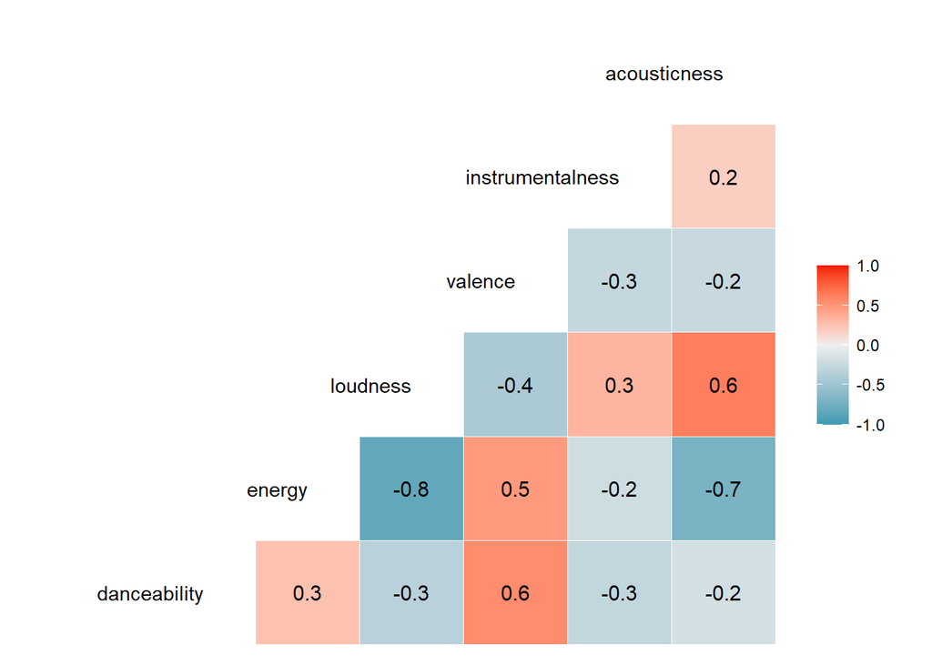

```r
# mengecek korelasi antar variabel prediktor numerik
ggcorr(song_clean, hjust = 1, layout.exp = 1, label = TRUE)
```

Menurut gambar *heatmap* di atas, sepertinya terdapat beberapa variabel prediktor yang berhubungan kuat. Tetapi untuk sementara, hal ini diabaikan karena nanti akan dicek kembali melalui nilai VIF.

*Imbalanced class* adalah salah satu *concern* yang patut diperhatikan dalam pemodelan menggunakan *machine learning*. Oleh karenanya, cek apakah variabel target memiliki kelas dengan proporsi yang tidak seimbang.

```r
# mengecek keseimbangan kelas dari variabel target
prop.table(table(song_clean$class))
```

```
##
##     0     1
## 0.625 0.375
```

Berdasarkan proporsi di atas, dapat disimpulkan bahwa kelas masih seimbang, sehingga tidak perlu dilakukan *resampling*.

**Note:** kelas umumnya dinyatakan *imbalanced* jika memiliki proporsi 90/10 atau 95/5.

## 6. Pembagian *Training Set* dan *Testing Set*

```r
# membagi ke training set dan testing set
set.seed(100)

index <- initial_split(data = song_clean,
                       prop = 0.8,
                       strata = class)

song_train <- training(index)
song_test <- testing(index)
```

## 7. Regresi Logistik Biner

### 7.1 Membentuk Model

Pada metode ini, pemodelan dilakukan sebanyak dua kali, yaitu dengan membentuk:

- model_all: model dengan seluruh variabel prediktor
- model_backward: model yang dibentuk dari proses *backward-stepwise*

```r
# membentuk model dengan semua variabel prediktor
model_all <- glm(class ~ ., data = song_train, family = "binomial")
summary(model_all)
```

```
##
## Call:
## glm(formula = class ~ ., family = "binomial", data = song_train)
##
## Deviance Residuals:
##     Min       1Q   Median       3Q      Max
## -2.0813  -0.5139  -0.1297   0.4979   2.6594
##
## Coefficients:
##                  Estimate Std. Error z value Pr(>|z|)
## (Intercept)       -0.7436     1.6641  -0.447 0.654990
## danceability      -1.9824     1.4360  -1.380 0.167439
## energy             3.0088     1.7111   1.758 0.078680 .
## loudness          10.6648     2.1069   5.062 4.15e-07 ***
## valence           -8.6922     1.5274  -5.691 1.27e-08 ***
## instrumentalness  -2.3121     0.5811  -3.979 6.93e-05 ***
## acousticness      -3.2749     0.9281  -3.529 0.000418 ***
## modemajor         -1.1016     0.3852  -2.860 0.004240 **
## ---
## Signif. codes:  0 '***' 0.001 '**' 0.01 '*' 0.05 '.' 0.1 ' ' 1
##
## (Dispersion parameter for binomial family taken to be 1)
##
##     Null deviance: 346.40  on 261  degrees of freedom
## Residual deviance: 187.86  on 254  degrees of freedom
## AIC: 203.86
##
## Number of Fisher Scoring iterations: 6
```

```r
# melakukan feature selection dengan metode backward
step(model_all, direction = "backward", trace = 0)
```

[output not shown]

```r
# membuat model menggunakan prediktor yang dihasilkan oleh metode backward
model_backward <- glm(class ~ danceability + loudness + valence + instrumentalness +
    acousticness + mode, data = song_train, family = "binomial")
summary(model_backward)
```

```
##
## Call:
## glm(formula = class ~ danceability + loudness + valence + instrumentalness +
##     acousticness + mode, family = "binomial", data = song_train)
##
## Deviance Residuals:
##     Min       1Q   Median       3Q      Max
## -2.3336  -0.5467  -0.1386   0.4876   2.5055
##
## Coefficients:
##                  Estimate Std. Error z value Pr(>|z|)
## (Intercept)        1.7970     0.8649   2.078 0.037753 *
## danceability      -2.3737     1.4036  -1.691 0.090816 .
## loudness           8.2883     1.5372   5.392 6.97e-08 ***
## valence           -7.5699     1.3129  -5.766 8.12e-09 ***
## instrumentalness  -2.1367     0.5674  -3.766 0.000166 ***
## acousticness      -4.0444     0.8379  -4.827 1.39e-06 ***
## modemajor         -1.0191     0.3797  -2.684 0.007269 **
## ---
## Signif. codes:  0 '***' 0.001 '**' 0.01 '*' 0.05 '.' 0.1 ' ' 1
##
## (Dispersion parameter for binomial family taken to be 1)
##
##     Null deviance: 346.40  on 261  degrees of freedom
## Residual deviance: 191.04  on 255  degrees of freedom
## AIC: 205.04
##
## Number of Fisher Scoring iterations: 6
```

### 7.2 Melakukan Prediksi

Setelah membuat model, langkah selanjutnya adalah melakukan prediksi.

Labelling pada *project* ini dilakukan dengan acuan:

- Jika probabilitas > 0,5 : `class` adalah 1
- Jika probabilitas <= 0,5 : `class` adalah 0

```r
# memprediksi pada training set menggunakan model_all
song_train$pred_prob_all <- predict(object = model_all, newdata = song_train, type="response")

# melakukan labelling pada hasil prediksi model_all di training set
song_train$pred_label_all <- ifelse(song_train$pred_prob_all > 0.5, 1, 0) %>% as.factor()
```

```r
# memprediksi pada testing set menggunakan model_all
song_test$pred_prob_all <- predict(object = model_all, newdata = song_test, type="response")

# melakukan labelling pada hasil prediksi model_all di testing set
song_test$pred_label_all <- ifelse(song_test$pred_prob_all > 0.5, 1, 0) %>% as.factor()
```

```r
# memprediksi pada training set menggunakan model_backward
song_train$pred_prob_backward <- predict(object = model_backward, newdata = song_train, type="response")

# melakukan labelling pada hasil prediksi model_backward di training set
song_train$pred_label_backward <- ifelse(song_train$pred_prob_backward > 0.5, 1, 0) %>% as.factor()
```

```r
# memprediksi pada testing set menggunakan model_backward
song_test$pred_prob_backward <- predict(object = model_backward, newdata = song_test, type="response")

# melakukan labelling pada hasil prediksi model_backward di testing set
song_test$pred_label_backward <- ifelse(song_test$pred_prob_backward > 0.5, 1, 0) %>% as.factor()
```